# R Notebook

```r
library(dplyr)
setwd("~/OneDrive\ -\ Michigan\ State\ University/Manning_lab/Mastitis_project/GitHub/data/")

ARGs <- read.table("abundance_ARGs_abs_COSMOS-ID.tsv", sep = "\t", header = TRUE,  na.strings = "", check.names = F)
metadata =read.table("metadata.csv", sep = ",", header = TRUE,  na.strings = "")
metadata$Treatment <- factor(metadata$Treatment, levels = c("Control", "Antibiotic"))
```

#BETA-LACTAMS

```r
betalactam_mx <- ARGs %>%
  select(Drug_Class, metadata$Name)

library(reshape2)
betalactam_df <- betalactam_mx %>%
  melt(id = colnames(betalactam_mx)[1]) %>%
  dplyr::rename(Name = variable, Abundance = value) %>%
  group_by(Drug_Class, Name) %>%
  dplyr::filter(Drug_Class %in% "Beta-lactam") %>%
  summarise(Abundance_score = sum(Abundance)) %>%
  merge(metadata)
```

##Difference between day -1 and week 1 within the same treatment group

```r
library(dplyr)
library(rstatix)
`%notin%` <- Negate(`%in%`)

stat.test <- betalactam_df %>%
  dplyr::filter(`Abundance_score` %notin% NA, study_ID %notin% "MA027", Time_tx %notin% "Week 11") %>%
  filter(Time_tx %in% c("Week 1", "Day -1")) %>%
  dplyr::group_by(Treatment) %>%
  rstatix::wilcox_test(`Abundance_score` ~ Time_tx, alternative = "less", paired = T) %>%
 rstatix::adjust_pvalue(method = "none") %>%
  rstatix::add_significance("p.adj")
stat.test
```

| Treatment | .y. | group1 | group2 | n1 | n2 | statistic | p | p.adj | p.adj.signif |
| --- | --- | --- | --- | --- | --- | --- | --- | --- | --- |
| Control | Abundance_score | Day -1 | Week 1 | 20 | 20 | 69 | 9.47e-02 | 9.47e-02 | ns |
| Antibiotic | Abundance_score | Day -1 | Week 1 | 20 | 20 | 5 | 9.54e-06 | 9.54e-06 | **** |

##Difference between treatment groups by time point (day -1, week 1-5), PAIRED TEST

```r
library(dplyr)
library(rstatix)
`%notin%` <- Negate(`%in%`)

stat.test <- betalactam_df %>%
  dplyr::filter(`Abundance_score` %notin% NA, study_ID %notin% "MA027", Time_tx %notin% c("Week 9")) %>% #Filtering MA027 because it was drawn from the study in week 1. Not including weeks 7 and 9 because one animal was drawn from the study in week 7 (see chunk below) and the analysis could not be paired for those weeks. Not including Week 11 because we only took samples of 4 out of 20 animals in that week.
  dplyr::group_by(Time_tx) %>%
  rstatix::wilcox_test(`Abundance_score` ~ Treatment, alternative = "less", paired = T) %>%
 rstatix::adjust_pvalue(method = "none") %>%
  rstatix::add_significance("p.adj")
stat.test
```

| Time_tx | .y. | group1 | group2 | n1 | n2 | statistic | p | p.adj | p.adj.signif |
| --- | --- | --- | --- | --- | --- | --- | --- | --- | --- |
| Day -1 | Abundance_score | Control | Antibiotic | 20 | 20 | 109 | 0.5650 | 0.5650 | ns |
| Week 1 | Abundance_score | Control | Antibiotic | 20 | 20 | 46 | 0.0133 | 0.0133 | * |
| Week 5 | Abundance_score | Control | Antibiotic | 20 | 20 | 100 | 0.4350 | 0.4350 | ns |

##Difference between treatment groups by time point, weeks 7 and 9 PAIRED (1 cow was draw of the study on week7)

```r
library(dplyr)
library(rstatix)
`%notin%` <- Negate(`%in%`)

stat.test <- betalactam_df %>%
  dplyr::filter(`Abundance_score` %notin% NA, study_ID %notin% c("MA027","MA028"), Time_tx %in% c("Week 9")) %>% #Filtering MA028 because it was paired with MA029 which was drawn from the study on week 7
  dplyr::group_by(Time_tx) %>%
  rstatix::wilcox_test(`Abundance_score` ~ Treatment, alternative = "less", paired = T) %>%
 rstatix::adjust_pvalue(method = "none") %>%
  rstatix::add_significance("p.adj")
stat.test
```

| Time_tx | .y. | group1 | group2 | n1 | n2 | statistic | p | p.adj | p.adj.signif |
| --- | --- | --- | --- | --- | --- | --- | --- | --- | --- |
| Week 9 | Abundance_score | Control | Antibiotic | 19 | 19 | 40 | 0.0129 | 0.0129 | * |

##Significance over the time period (regardless of treatment)

```r
stat.test <- betalactam_df %>%
  dplyr::filter(`Abundance_score` %notin% NA) %>%
  kruskal_test(`Abundance_score` ~ Time_tx)
stat.test
```

|  | .y. | n | statistic | df | p | method |
| --- | --- | --- | --- | --- | --- | --- |
| 1 | Abundance_score | 159 | 22.25197 | 3 | 5.78e-05 | Kruskal-Wallis |

##Beta-lactams plot

```r
library(ggpubr)
```

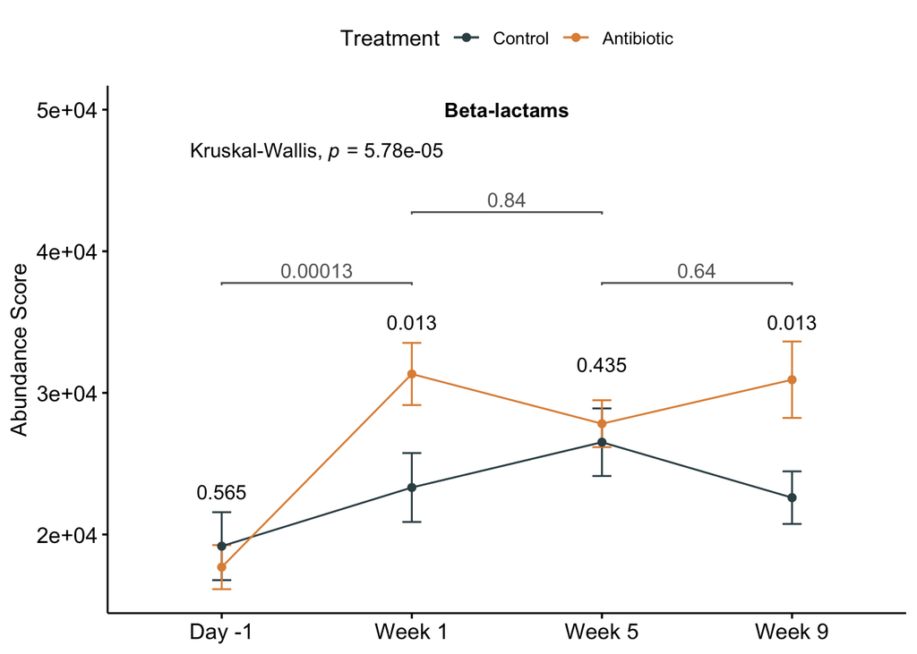

```r
library(ggsci)
betalactam_plot <- betalactam_df %>%
  ggline(x = "Time_tx", y = "Abundance_score", color = "Treatment", add = c("mean_se"),
         ylab = "Abundance Score", palette = "jama") +
  scale_y_continuous(labels = function(x) format(x, scientific = TRUE)) +
  annotate("text", x = 1, y = 2.3e+04, label = expression("0.565"), colour = "black") +
  annotate("text", x = 2, y = 3.5e+04, label = expression("0.013"), colour = "black") +
  annotate("text", x = 3, y = 3.2e+04, label = expression("0.435"), colour = "black") +
  annotate("text", x = 4, y = 3.5e+04, label = expression("0.013"), colour = "black") +
  annotate("text", x = 2.5, y = 5e+04, label = expression(bold("Beta-lactams"))) +
  annotate("text", x = 1.5, y = 4.7e+04, label = expression(paste("Kruskal-Wallis, ", paste(italic('p'))," = 5.78e-05"))) +
  geom_signif(aes(y = `Abundance_score`, x = Time_tx),comparisons = list(c("Day -1","Week 1"),
                                                                 c("Week 1","Week 5"),
                                                                 c("Week 5","Week 9")),
              test = "wilcox.test", y_position = c(3.5e+04,4e+04,3.5e+04), color = "gray40", tip_length = 0.002, test.args=list(alternative = "two.sided", var.equal = FALSE, paired=FALSE)) +
  theme(axis.title.x = element_blank())

betalactam_plot
```

#bla-CFXA

```r
genes_mx <- ARGs %>%
  select(ARG_group, metadata$Name)

library(reshape2)
cfxa_df <- genes_mx %>%
  melt(id = colnames(genes_mx)[1]) %>%
  dplyr::rename(Name = variable, Abundance = value) %>%
  group_by(ARG_group, Name) %>%
  dplyr::filter(ARG_group %in% "blaCFXA") %>%
  summarise(Abundance_score = sum(Abundance)) %>%
  merge(metadata)
```

##Difference between day -1 and week 1 within the same treatment group

```r
library(dplyr)
library(rstatix)
`%notin%` <- Negate(`%in%`)

stat.test <- cfxa_df %>%
  dplyr::filter(`Abundance_score` %notin% NA, study_ID %notin% "MA027", Time_tx %notin% "Week 11") %>%
  filter(Time_tx %in% c("Week 1", "Day -1")) %>%
  dplyr::group_by(Treatment) %>%
  rstatix::wilcox_test(`Abundance_score` ~ Time_tx, alternative = "less", paired = T) %>%
 rstatix::adjust_pvalue(method = "none") %>%
  rstatix::add_significance("p.adj")
stat.test
```

| Treatment | .y. | group1 | group2 | n1 | n2 | statistic | p | p.adj | p.adj.signif |
| --- | --- | --- | --- | --- | --- | --- | --- | --- | --- |
| Control | Abundance_score | Day -1 | Week 1 | 20 | 20 | 76 | 1.47e-01 | 1.47e-01 | ns |
| Antibiotic | Abundance_score | Day -1 | Week 1 | 20 | 20 | 13 | 8.39e-05 | 8.39e-05 | **** |

##Difference between treatment groups by time point (day -1, week 1-5), PAIRED TEST

```r
library(dplyr)
library(rstatix)
`%notin%` <- Negate(`%in%`)

stat.test <- cfxa_df %>%
  dplyr::filter(`Abundance_score` %notin% NA, study_ID %notin% "MA027", Time_tx %notin% c("Week 9")) %>% #Filtering MA027 because it was drawn from the study in week 1. Not including weeks 7 and 9 because one animal was drawn from the study in week 7 (see chunk below) and the analysis could not be paired for those weeks. Not including Week 11 because we only took samples of 4 out of 20 animals in that week.
  dplyr::group_by(Time_tx) %>%
  rstatix::wilcox_test(`Abundance_score` ~ Treatment, alternative = "less", paired = T) %>%
 rstatix::adjust_pvalue(method = "none") %>%
  rstatix::add_significance("p.adj")
stat.test
```

| Time_tx | .y. | group1 | group2 | n1 | n2 | statistic | p | p.adj | p.adj.signif |
| --- | --- | --- | --- | --- | --- | --- | --- | --- | --- |
| Day -1 | Abundance_score | Control | Antibiotic | 20 | 20 | 111 | 0.5940 | 0.5940 | ns |
| Week 1 | Abundance_score | Control | Antibiotic | 20 | 20 | 47 | 0.0148 | 0.0148 | * |
| Week 5 | Abundance_score | Control | Antibiotic | 20 | 20 | 113 | 0.6220 | 0.6220 | ns |

##Difference between treatment groups by time point, weeks 7 and 9 PAIRED (1 cow was draw of the study on week7)

```r
library(dplyr)
library(rstatix)
`%notin%` <- Negate(`%in%`)

stat.test <- cfxa_df %>%
  dplyr::filter(`Abundance_score` %notin% NA, study_ID %notin% c("MA027","MA028"), Time_tx %in% c("Week 9")) %>% #Filtering MA028 because it was paired with MA029 which was drawn from the study on week 7
  dplyr::group_by(Time_tx) %>%
  rstatix::wilcox_test(`Abundance_score` ~ Treatment, alternative = "less", paired = T) %>%
 rstatix::adjust_pvalue(method = "none") %>%
  rstatix::add_significance("p.adj")
stat.test
```

| Time_tx | .y. | group1 | group2 | n1 | n2 | statistic | p | p.adj | p.adj.signif |
| --- | --- | --- | --- | --- | --- | --- | --- | --- | --- |
| Week 9 | Abundance_score | Control | Antibiotic | 19 | 19 | 42 | 0.0162 | 0.0162 | * |

##Significance over the time period (regardless of treatment)

```r
stat.test <- cfxa_df %>%
  dplyr::filter(`Abundance_score` %notin% NA) %>%
  kruskal_test(`Abundance_score` ~ Time_tx)
stat.test
```

|  | .y. | n | statistic | df | p | method |
| --- | --- | --- | --- | --- | --- | --- |
| 1 | Abundance_score | 159 | 20.98485 | 3 | 0.000106 | Kruskal-Wallis |

##CFXA plot

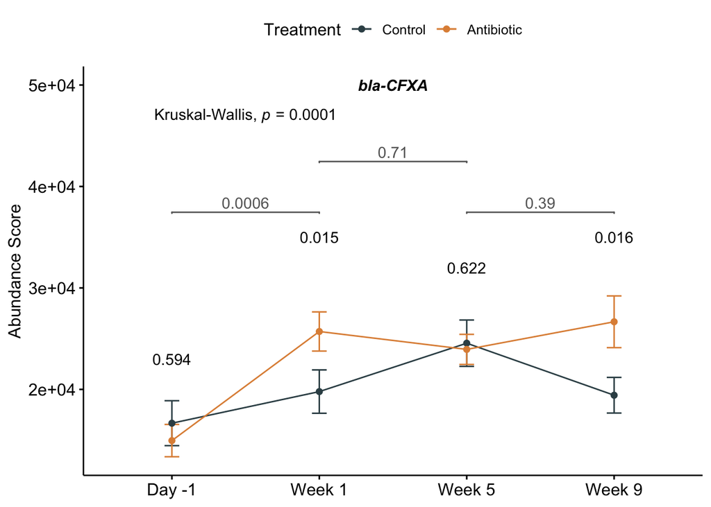

```r
library(ggpubr)
cfxa_plot <- cfxa_df %>%
  ggline(x = "Time_tx", y = "Abundance_score", color = "Treatment", add = c("mean_se"),
         ylab = "Abundance Score", palette = "jama") +
  scale_y_continuous(labels = function(x) format(x, scientific = TRUE)) +
  annotate("text", x = 1, y = 2.3e+04, label = expression("0.594"), colour = "black") +
  annotate("text", x = 2, y = 3.5e+04, label = expression("0.015"), colour = "black") +
  annotate("text", x = 3, y = 3.2e+04, label = expression("0.622"), colour = "black") +
  annotate("text", x = 4, y = 3.5e+04, label = expression("0.016"), colour = "black") +
    annotate("text", x = 2.5, y = 5e+04, label = expression(bolditalic("bla-CFXA"))) +
  annotate("text", x = 1.5, y = 4.7e+04, label = expression(paste("Kruskal-Wallis, ", paste(italic('p'))," = 0.0001"))) +
  geom_signif(aes(y = `Abundance_score`, x = Time_tx),comparisons = list(c("Day -1","Week 1"),
                                                                 c("Week 1","Week 5"),
                                                                 c("Week 5","Week 9")),
              test = "wilcox.test", y_position = c(3.5e+04,4e+04,3.5e+04), color = "gray40", tip_length = 0.002, test.args=list(alternative = "two.sided", var.equal = FALSE, paired=FALSE)) +
  theme(axis.title.x = element_blank())

cfxa_plot
```

#bla-CMY

```r
library(reshape2)
cmy_df <- genes_mx %>%
  melt(id = colnames(genes_mx)[1]) %>%
  dplyr::rename(Name = variable, Abundance = value) %>%
  group_by(ARG_group, Name) %>%
  dplyr::filter(ARG_group %in% "blaCMY") %>%
  summarise(Abundance_score = sum(Abundance)) %>%
  merge(metadata)
```

##Difference between day -1 and week 1 within the same treatment group

```r
library(dplyr)
library(rstatix)
`%notin%` <- Negate(`%in%`)

stat.test <- cmy_df %>%
  dplyr::filter(`Abundance_score` %notin% NA, study_ID %notin% "MA027", Time_tx %notin% "Week 11") %>%
  filter(Time_tx %in% c("Week 1", "Day -1")) %>%
  dplyr::group_by(Treatment) %>%
  rstatix::wilcox_test(`Abundance_score` ~ Time_tx, alternative = "less", paired = T) %>%
 rstatix::adjust_pvalue(method = "none") %>%
  rstatix::add_significance("p.adj")
stat.test
```

| Treatment | .y. | group1 | group2 | n1 | n2 | statistic | p | p.adj | p.adj.signif |
| --- | --- | --- | --- | --- | --- | --- | --- | --- | --- |
| Control | Abundance_score | Day -1 | Week 1 | 20 | 20 | 3 | 0.9630 | 0.9630 | ns |
| Antibiotic | Abundance_score | Day -1 | Week 1 | 20 | 20 | 0 | 0.0907 | 0.0907 | ns |

##Difference between treatment groups by time point (day -1, week 1-5), PAIRED TEST

```r
library(dplyr)
library(rstatix)
`%notin%` <- Negate(`%in%`)

stat.test <- cmy_df %>%
  dplyr::filter(`Abundance_score` %notin% NA, study_ID %notin% "MA027", Time_tx %notin% c("Week 9")) %>% #Filtering MA027 because it was drawn from the study in week 1. Not including weeks 7 and 9 because one animal was drawn from the study in week 7 (see chunk below) and the analysis could not be paired for those weeks. Not including Week 11 because we only took samples of 4 out of 20 animals in that week.
  dplyr::group_by(Time_tx) %>%
  rstatix::wilcox_test(`Abundance_score` ~ Treatment, alternative = "less", paired = T) %>%
 rstatix::adjust_pvalue(method = "none") %>%
  rstatix::add_significance("p.adj")
stat.test
```

| Time_tx | .y. | group1 | group2 | n1 | n2 | statistic | p | p.adj | p.adj.signif |
| --- | --- | --- | --- | --- | --- | --- | --- | --- | --- |
| Day -1 | Abundance_score | Control | Antibiotic | 20 | 20 | 3 | 0.9630 | 0.9630 | ns |
| Week 1 | Abundance_score | Control | Antibiotic | 20 | 20 | 2 | 0.1810 | 0.1810 | ns |
| Week 5 | Abundance_score | Control | Antibiotic | 20 | 20 | 0 | 0.0907 | 0.0907 | ns |

##Difference between treatment groups by time point, weeks 7 and 9 PAIRED (1 cow was draw of the study on week7)

```r
library(dplyr)
library(rstatix)
`%notin%` <- Negate(`%in%`)

stat.test <- cmy_df %>%
  dplyr::filter(`Abundance_score` %notin% NA, study_ID %notin% c("MA027","MA028"), Time_tx %in% c("Week 9")) %>% #Filtering MA028 because it was paired with MA029 which was drawn from the study on week 7
  dplyr::group_by(Time_tx) %>%
  rstatix::wilcox_test(`Abundance_score` ~ Treatment, alternative = "less", paired = T) %>%
 rstatix::adjust_pvalue(method = "none") %>%
  rstatix::add_significance("p.adj")
stat.test
```

| Time_tx | .y. | group1 | group2 | n1 | n2 | statistic | p | p.adj | p.adj.signif |
| --- | --- | --- | --- | --- | --- | --- | --- | --- | --- |
| Week 9 | Abundance_score | Control | Antibiotic | 19 | 19 | 0 | 0.0295 | 0.0295 | * |

##Significance over the time period (regardless of treatment)

```r
stat.test <- cmy_df %>%
  dplyr::filter(`Abundance_score` %notin% NA) %>%
  kruskal_test(`Abundance_score` ~ Time_tx)
stat.test
```

|  | .y. | n | statistic | df | p | method |
| --- | --- | --- | --- | --- | --- | --- |
| 1 | Abundance_score | 159 | 1.598741 | 3 | 0.66 | Kruskal-Wallis |

##CMY plot

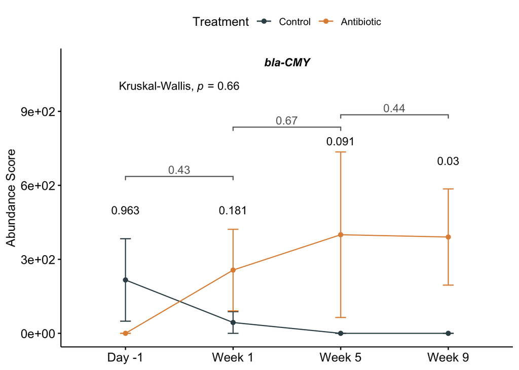

```r
library(ggpubr)
cmy_plot <- cmy_df %>%
  ggline(x = "Time_tx", y = "Abundance_score", color = "Treatment", add = c("mean_se"),
         ylab = "Abundance Score", palette = "jama") +
  scale_y_continuous(labels = function(x) format(x, scientific = TRUE)) +
  annotate("text", x = 1, y = 5e+02, label = expression("0.963"), colour = "black") +
  annotate("text", x = 2, y = 5e+02, label = expression("0.181"), colour = "black") +
  annotate("text", x = 3, y = 7.8e+02, label = expression("0.091"), colour = "black") +
  annotate("text", x = 4, y = 7e+02, label = expression("0.03"), colour = "black") +
      annotate("text", x = 2.5, y = 1.1e+03, label = expression(bolditalic("bla-CMY"))) +
  annotate("text", x = 1.5, y = 1e+03, label = expression(paste("Kruskal-Wallis, ", paste(italic('p'))," = 0.66"))) +
  geom_signif(aes(y = `Abundance_score`, x = Time_tx),comparisons = list(c("Day -1","Week 1"),
                                                                 c("Week 1","Week 5"),
                                                                 c("Week 5","Week 9")),
              test = "wilcox.test", y_position = c(3e+02,5e+02,5.5e+02), color = "gray40", tip_length = 0.002, test.args=list(alternative = "two.sided", var.equal = FALSE, paired=FALSE)) +
  theme(axis.title.x = element_blank())

cmy_plot
```

#blc

```r
library(reshape2)
blc_df <- genes_mx %>%
  melt(id = colnames(genes_mx)[1]) %>%
  dplyr::rename(Name = variable, Abundance = value) %>%
  group_by(ARG_group, Name) %>%
  dplyr::filter(ARG_group %in% "blc") %>%
  summarise(Abundance_score = sum(Abundance)) %>%
  merge(metadata)
```

##Difference between day -1 and week 1 within the same treatment group

```r
library(dplyr)
library(rstatix)
`%notin%` <- Negate(`%in%`)

stat.test <- blc_df %>%
  dplyr::filter(`Abundance_score` %notin% NA, study_ID %notin% "MA027", Time_tx %notin% "Week 11") %>%
  filter(Time_tx %in% c("Week 1", "Day -1")) %>%
  dplyr::group_by(Treatment) %>%
  rstatix::wilcox_test(`Abundance_score` ~ Time_tx, alternative = "less", paired = T) %>%
 rstatix::adjust_pvalue(method = "none") %>%
  rstatix::add_significance("p.adj")
stat.test
```

| Treatment | .y. | group1 | group2 | n1 | n2 | statistic | p | p.adj | p.adj.signif |
| --- | --- | --- | --- | --- | --- | --- | --- | --- | --- |
| Control | Abundance_score | Day -1 | Week 1 | 20 | 20 | 0 | 0.1860 | 0.1860 | ns |
| Antibiotic | Abundance_score | Day -1 | Week 1 | 20 | 20 | 1 | 0.0104 | 0.0104 | * |

##Difference between treatment groups by time point (day -1, week 1-5), PAIRED TEST

```r
library(dplyr)
library(rstatix)
`%notin%` <- Negate(`%in%`)

stat.test <- blc_df %>%
  dplyr::filter(`Abundance_score` %notin% NA, study_ID %notin% "MA027", Time_tx %notin% c("Week 9")) %>% #Filtering MA027 because it was drawn from the study in week 1. Not including weeks 7 and 9 because one animal was drawn from the study in week 7 (see chunk below) and the analysis could not be paired for those weeks. Not including Week 11 because we only took samples of 4 out of 20 animals in that week.
  dplyr::group_by(Time_tx) %>%
  rstatix::wilcox_test(`Abundance_score` ~ Treatment, alternative = "less", paired = T) %>%
 rstatix::adjust_pvalue(method = "none") %>%
  rstatix::add_significance("p.adj")
stat.test
```

| Time_tx | .y. | group1 | group2 | n1 | n2 | statistic | p | p.adj | p.adj.signif |
| --- | --- | --- | --- | --- | --- | --- | --- | --- | --- |
| Day -1 | Abundance_score | Control | Antibiotic | 20 | 20 | 0 | 0.5000 | 0.5000 | ns |
| Week 1 | Abundance_score | Control | Antibiotic | 20 | 20 | 10 | 0.0776 | 0.0776 | ns |
| Week 5 | Abundance_score | Control | Antibiotic | 20 | 20 | 0 | 0.0112 | 0.0112 | * |

##Difference between treatment groups by time point, weeks 7 and 9 PAIRED (1 cow was draw of the study on week7)

```r
library(dplyr)
library(rstatix)
`%notin%` <- Negate(`%in%`)

stat.test <- blc_df %>%
  dplyr::filter(`Abundance_score` %notin% NA, study_ID %notin% c("MA027","MA028"), Time_tx %in% c("Week 9")) %>% #Filtering MA028 because it was paired with MA029 which was drawn from the study on week 7
  dplyr::group_by(Time_tx) %>%
  rstatix::wilcox_test(`Abundance_score` ~ Treatment, alternative = "less", paired = T) %>%
 rstatix::adjust_pvalue(method = "none") %>%
  rstatix::add_significance("p.adj")
stat.test
```

| Time_tx | .y. | group1 | group2 | n1 | n2 | statistic | p | p.adj | p.adj.signif |
| --- | --- | --- | --- | --- | --- | --- | --- | --- | --- |
| Week 9 | Abundance_score | Control | Antibiotic | 19 | 19 | 0 | 0.0907 | 0.0907 | ns |

##Significance over the time period (regardless of treatment)

```r
stat.test <- blc_df %>%
  dplyr::filter(`Abundance_score` %notin% NA) %>%
  kruskal_test(`Abundance_score` ~ Time_tx)
stat.test
```

|  | .y. | n | statistic | df | p | method |
| --- | --- | --- | --- | --- | --- | --- |
| 1 | Abundance_score | 159 | 10.44123 | 3 | 0.0152 | Kruskal-Wallis |

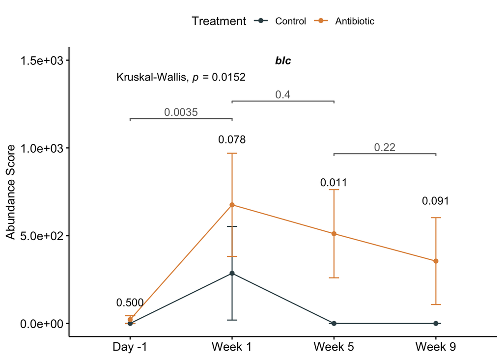

```r
library(ggpubr)
blc_plot <- blc_df %>%
  ggline(x = "Time_tx", y = "Abundance_score", color = "Treatment", add = c("mean_se"),
         ylab = "Abundance Score", palette = "jama") +
  scale_y_continuous(labels = function(x) format(x, scientific = TRUE)) +
  annotate("text", x = 1, y = 1.2e+02, label = expression("0.500"), colour = "black") +
  annotate("text", x = 2, y = 1.05e+03, label = expression("0.078"), colour = "black") +
  annotate("text", x = 3, y = 8.05e+02, label = expression("0.011"), colour = "black") +
  annotate("text", x = 4, y = 7e+02, label = expression("0.091"), colour = "black") +
  annotate("text", x = 2.5, y = 1.5e+03, label = expression(bolditalic("blc"))) +
  annotate("text", x = 1.5, y = 1.4e+03, label = expression(paste("Kruskal-Wallis, ", paste(italic('p'))," = 0.0152"))) +
  geom_signif(aes(y = `Abundance_score`, x = Time_tx),comparisons = list(c("Day -1","Week 1"),
                                                                 c("Week 1","Week 5"),
                                                                 c("Week 5","Week 9")),
              test = "wilcox.test", y_position = c(.9e+03,1e+03,7e+02), color = "gray40", tip_length = 0.002, test.args=list(alternative = "two.sided", var.equal = FALSE, paired=FALSE)) +
  theme(axis.title.x = element_blank())

blc_plot
```

#Arranging plots in one figure

```r
betalactam_plots <- ggarrange(betalactam_plot, cfxa_plot, cmy_plot, blc_plot, labels = c("A", "B","C","D"), nrow = 2, ncol = 2, common.legend = T)
```

[output not shown]

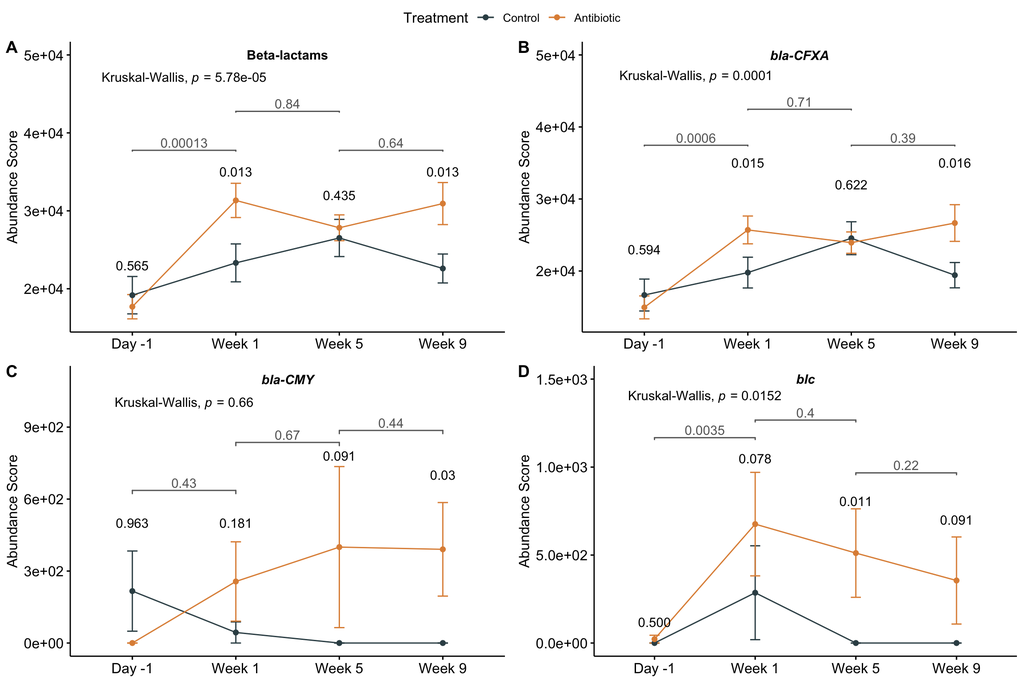

```r
betalactam_plots
```

```r
setwd("~/OneDrive\ -\ Michigan\ State\ University/Manning_lab/Mastitis_project/figures")

ggsave(plot = betalactam_plots, "betalactam_line_plots.png", width = 12, height = 8)
```